Home > Introduction > What is Data Science?

# 1.0 - What is Data Science?

Extract information from Data

#### Example 1

Years of study / salary relation 1. Understand the relation between an “input” and an “output” 2. Find a function that roughly estimates the data points (called *regression*)

#### Other examples

- Using user rating to generate movie recommendations
- Label an entire dataset from only a few labels
- Classify data
  - Whole dataset is labeled (e.g. Cats and Dogs)
  - Draw a new sample (take a new image) and classify it (as a Dog or a Cat)

## 3 Fields

1. Supervised learning
   - classification / regression
2. Unsupervised learning
   - clustering
   - you only have data and no information on it
3. Semi-supervised learning
   - if you have a few labels and you want to infer all the labels

### Terminology

step size = learning rate

## Example: The income dataset

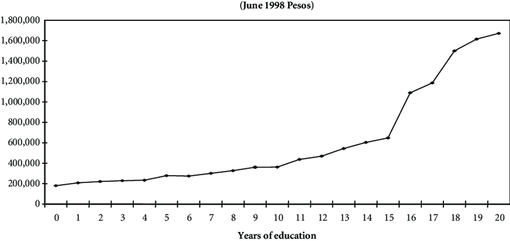

The data points ($x_i, y_i$) $\in \mathbb{R}^2$ are supposed to be of the form
$$y_i = f(x_i) + \epsilon \hspace{3mm} ( \epsilon
\rightarrow \text{noise})$$
**Remark**: In general, the function $f$ is *unknown* We want to approximate this function $f$ using the data! Find an approximation $\hat{f}$ of $f$ using {($x_i, y_i)$}$_{1 \leq i \leq N}$

## Nearest neighbours interpolation

The nearest neighbours interpolation of {($x_i, y_i)$}$_{1 \leq i \leq N}$ is the function
$$x
\Rightarrow \hat{f}(x) = y_{i*}$$
This means for an input $x$ you find the nearest data point $x_i$ (i.e. the one with the smallest absolute distance to $x$) and assign its corresponding value $y_i$ to $\hat{f}(x)$

when $i_x \in \text{argmin}_{1 \leq i \leq N} |x - x_i|$

- Perfectly fits the data, i.e. $\hat{f}(x_i) = y_i$
- However, its sensible to outlayers
  - **Outlayers**: Some point in the graph is somehow not along the expected function (imagine point (18, 40,000)), which is very far from the function we are seeking

Next up: 1.1 Linear Regression